# Web Scraping - Soccer tables

# Web Scraping project: gather soccer tables

Project’s objectives:

1. To practice mining data from online website using `rvest`
2. To clean up the mined data into ready-to-use data.frame
3. To do exploratory data analysis
4. To study possible connection between points earned and clubs’ performances and to build predictive models

Libraries

```r
library('rvest', lib='C:/temp')
library('ggplot2', lib='C:/temp')
library('ggrepel', lib='C:/temp')
library('ggthemes', lib='C:/temp')
library('tidyverse', lib='C:/temp')
library('kableExtra', lib='C:/temp')
```

## Part 1: Functions to get tables from multiple pages

In mining the data needed, I used the package `rvest`, [link](https://github.com/tidyverse/rvest), together with web browser `SelectorGadget`, [link](https://selectorgadget.com/).

The data is from ESPN, an example of which is [link](http://www.espn.com/soccer/standings/_/league/ita.1/season/2017). Once I extracted into `R`, the tables from ESPN contained several pieces of data that were not related, such as:

```r
urlsample <- 'http://www.espn.com/soccer/standings/_/league/ita.1/season/2017'
# Raw web info
web <- urlsample %>%
  read_html() %>%
  html_nodes('.stat-cell , .pr3 , .subHeader__item--content , #fittPageContainer a') %>%
  html_text()
matrix(web[c(1:4,79:106)], ncol = 4, byrow =T)
```

```
##      [,1]        [,2]        [,3]  [,4]
## [1,] "2017/2018" "2017/2018" "1"   ""
## [2,] "20"        ""          "BEN" "Benevento"
## [3,] "GP"        "GP"        "GP"  "W"
## [4,] "W"         "W"         "D"   "D"
## [5,] "D"         "L"         "L"   "L"
## [6,] "F"         "F"         "F"   "A"
## [7,] "A"         "A"         "GD"  "GD"
## [8,] "GD"        "P"         "P"   "P"
```

```r
unrelatedrows <- c()
for (i in 0:3) {
  temp <- substr(web[length(web)-i],1,20)
  unrelatedrows <- c(unrelatedrows, temp)
}
unrelatedrows
```

```
## [1] "All Serie A News"     "Bonetti: Juve will g" "10 man Milan hang on"
## [4] "Will Man United relo"
```

The first 2 rows were the current table’s season, and this number was fixed across all leagues and seasons. The last 4 rows were news related to the current league, and this number varied across different leagues, for example the Italian league had 4, and the Portugese league had 11 of them. The middle `GP`, `D`, … were the table columns’ names, they stood for:

1. `GP`: Games played
2. `W`: Wins
3. `D`: Draws
4. `L`: Losses
5. `F`: Goals For
6. `A`: Goals Against
7. `GD`: Goals Difference
8. `P`: Points

Each of these names were repeated 3 times across all leagues and seasons, and were at fixed positions: after information about the clubs in the league.

In dealing with the varying unrelated rows at the end, I wrote a function `check_link(url)` to check for the number of such rows.

#### 1.1. `check_link(url)`: function to check # unrelated rows at end of raw table

Function will return the #(rows) to be removed at the end of table

```r
check_link <- function(url) {
  url <- url
  # Raw web info
  web <- url %>%
    read_html() %>%
    html_nodes('.stat-cell , .pr3 , .subHeader__item--content , #fittPageContainer a') %>%
    html_text()
  # Flag: F if cell is string, T if cell is number: which is wanted
  flag <- FALSE
  # counter
  n <- 0
  while (flag == FALSE) {
    # Check for if current cell is a string
    if ( is.na(as.integer(web[length(web)-n]))) {
      # Yes: cell is string: increase count
      n <- n+1
    } else {
      # No: cell is number: Good
      flag <- TRUE
      n
    }
  }
  return(n)
}
```

After knowing that number, the desired rows were what remained. The function `get_table(url, leaguename, k)` helped automate the mining across different url addresses for different leagues and seasons.

#### 1.2. `get_table(url, leaguename, k)`: function to get table

```r
get_table <- function(url, leaguename, k) {
  web <- url %>%
    read_html() %>%
    html_nodes('.stat-cell , .pr3 , .subHeader__item--content , #fittPageContainer a') %>%
    html_text()

  # Get number of clubs for current season, by counting the number of unrelated rows
  # Top: 2, Middle: 24, for table headings: 8 unique values, each repeated 3x
  # Bottom: k, to be checked link-by-link
  n <- (length(web) - 2 - k - 24)/12

  # Get the season's year & League
  year <- rep(web[1], n)
  league <- rep(leaguename, n)
  # Filter out the unneeded rows
  web <- web[3:(length(web) - k)]

  # Dataframe of clubs
  df <- web %>%
    head(4*n) %>%
    matrix(nrow = n, byrow = T) %>%
    data.frame()
  # Dummy column: pos, to be referenced when mergin data.frames
  df$pos <- as.integer(as.character(df[,1]))

  # 1st 4*n rows are Club names, already used above
  web <- web %>% tail(length(web) - 4*n)

  # Temp data.frame of Clubs' attributes
  temp <- web %>%
    # Remove first 24 cells
    tail(length(web) - 24) %>%
    as.numeric() %>%
    # Convert to matrix, with n rows for n clubs
    matrix(nrow = n, byrow = T) %>%
    # Dummy var: position, to be referenced when merging 2 data.frames
    cbind(1:n) %>%
    data.frame()

  # Merge 2 data.frames
  df <- merge(df, temp, by.x = 'pos', by.y = 'X9')

  # Clean up the data.frame
  df <- df %>%
    select(-c(2,3)) %>%
    mutate(year = year,
           league = league)

  # Rename df
  colnames(df) <- c('Standing', 'Club_S', 'Club', 'Games', 'Wins', 'Draws', 'Losses',
               'G_For', 'G_Against', 'G_Diff', 'Points', 'Season', 'League')
  return(df)
}
```

## Part 2: Gather tables from leagues

In gathering the tables, my idea was to supply the link for each leagues, with the available years, the return of which would be a data.frame, to be appended to an empty data.frame created below.

#### National league tables

In checking the ESPN websites, I decided to gather information from the following leagues and the season years:

```r
# Default data.frame, to be added in
df <- data.frame()

leagues <- c('Italy', 'England', 'Spain', 'Germany', 'France', 'Netherland',
             'Portugal', 'Russia', 'Turkey', 'Greece', 'Brazil', 'Argentina')
years <- c('01/02 - 17/18', '01/02 - 17/18', '01/02 - 17/18', '01/02 - 17/18',
           '02/03 - 17/18', '01/02 - 17/18', '06/07 - 17/18', '06/07 - 16/17',
           '06/07 - 17/18', '06/07 - 17/18', '06 - 18', '03/04 - 17/18')
urls <- c('http://www.espn.com/soccer/standings/_/league/ita.1/season/2017',
         'http://www.espn.com/soccer/standings/_/league/eng.1/season/2017',
         'http://www.espn.com/soccer/standings/_/league/esp.1/season/2017',
         'http://www.espn.com/soccer/standings/_/league/ger.1/season/2017',
         'http://www.espn.com/soccer/standings/_/league/fra.1/season/2017',
         'http://www.espn.com/soccer/standings/_/league/ned.1/season/2017',
         'http://www.espn.com/soccer/standings/_/league/por.1/season/2017',
         'http://www.espn.com/soccer/standings/_/league/rus.1/season/2017',
         'http://www.espn.com/soccer/standings/_/league/tur.1/season/2017',
         'http://www.espn.com/soccer/standings/_/league/GRE.1/seasontype/1/season/2017',
         'http://www.espn.com/soccer/standings/_/league/bra.1/season/2017',
         'http://www.espn.com/soccer/standings/_/league/arg.1/season/2017')
data.frame(leagues, years, urls)
```

| leagues | years | urls |
| --- | --- | --- |
| Italy | 01/02 - 17/18 | http://www.espn.com/soccer/standings/_/league/ita.1/season/2017 |
| England | 01/02 - 17/18 | http://www.espn.com/soccer/standings/_/league/eng.1/season/2017 |
| Spain | 01/02 - 17/18 | http://www.espn.com/soccer/standings/_/league/esp.1/season/2017 |
| Germany | 01/02 - 17/18 | http://www.espn.com/soccer/standings/_/league/ger.1/season/2017 |
| France | 02/03 - 17/18 | http://www.espn.com/soccer/standings/_/league/fra.1/season/2017 |
| Netherland | 01/02 - 17/18 | http://www.espn.com/soccer/standings/_/league/ned.1/season/2017 |
| Portugal | 06/07 - 17/18 | http://www.espn.com/soccer/standings/_/league/por.1/season/2017 |
| Russia | 06/07 - 16/17 | http://www.espn.com/soccer/standings/_/league/rus.1/season/2017 |
| Turkey | 06/07 - 17/18 | http://www.espn.com/soccer/standings/_/league/tur.1/season/2017 |
| Greece | 06/07 - 17/18 | http://www.espn.com/soccer/standings/_/league/GRE.1/seasontype/1/season/2017 |

[output cut: 2 more lines]

#### Prepare and Set-up needed data.frames

1. Prepare data.frame of information on what to mine from the ESPN website:
   - Season year
   - League name
   - URL

```r
yrita <- c(2017:2001); yreng <- c(2017:2001); yresp <- c(2017:2001)
yrger <- c(2017:2001); yrfra <- c(2017:2002); yrned <- c(2017:2001)
yrpor <- c(2017:2010, 2008:2006); yrrus <- c(2016:2006)
yrtur <- c(2017:2006); yrgre <- c(2017:2016, 2014:2006)
yrbra <- c(2017:2006); yrarg <- c(2017, 2015:2003)
yrs <- c(yrita, yreng, yresp, yrger, yrfra, yrned, yrpor, yrrus, yrtur, yrgre, yrbra, yrarg)
leagues <-
  c(rep(c('Serie A', 'http://www.espn.com/soccer/standings/_/league/ita.1/season/'), length(yrita)),
    rep(c('EPL', 'http://www.espn.com/soccer/standings/_/league/eng.1/season/'), length(yreng)),
    rep(c('La Liga', 'http://www.espn.com/soccer/standings/_/league/esp.1/season/'), length(yresp)),
    rep(c('Bundesliga', 'http://www.espn.com/soccer/standings/_/league/ger.1/season/'), length(yrger)),
    rep(c('Ligue 1', 'http://www.espn.com/soccer/standings/_/league/fra.1/season/'), length(yrfra)),
    rep(c('Netherland', 'http://www.espn.com/soccer/standings/_/league/ned.1/season/'), length(yrned)),
    rep(c('Portugal', 'http://www.espn.com/soccer/standings/_/league/por.1/season/'), length(yrpor)),
    rep(c('Russia', 'http://www.espn.com/soccer/standings/_/league/rus.1/season/'), length(yrrus)),
    rep(c('Turkey', 'http://www.espn.com/soccer/standings/_/league/tur.1/season/'), length(yrtur)),
    rep(c('Greece', 'http://www.espn.com/soccer/standings/_/league/GRE.1/seasontype/1/season/'), length(yrgre)),
    rep(c('Brazil', 'http://www.espn.com/soccer/standings/_/league/bra.1/season/'), length(yrbra)),
    rep(c('Argentina', 'http://www.espn.com/soccer/standings/_/league/arg.1/season/'), length(yrarg))
    )

df_url <- data.frame(yrs, leagues[c(TRUE, FALSE)], leagues[c(FALSE, TRUE)])
colnames(df_url) <- c('Season', 'League', 'URL')
print(paste0('Dimension of the Information data.frame: ', dim(df_url)[1], ' x ', dim(df_url)[2]))
```

```
## [1] "Dimension of the Information data.frame: 172 x 3"
```

2. Get index of first instance of new league: to check for number of unrelated rows at end of table

This was the problem that the function `check_link(url)` from 1.1. was written to solve.

```r
# Step 1: Create intervals: only need to check 1st instance of new league, and not all of them
intervals <- c(length(yrita), length(yreng), length(yresp), length(yrger),
               length(yrfra), length(yrned), length(yrpor), length(yrrus),
               length(yrtur), length(yrgre), length(yrbra), length(yrarg))
# Step 2: Create an index of what to test
idx <- c(1 + cumsum(c(0, intervals)), end)
# to access idx, use idx[[i]]
print(paste0('Examples of such indices: ', idx[[1]], ', ', idx[[2]]))
```

```
## [1] "Examples of such indices: 1, 18"
```

#### 3. Gather the tables into the main data.frame

```r
for (i in 1:length(yrs)) {
  # Current season year
  season <- df_url$Season[i]
  # Current league name
  league <- df_url$League[i]
  # Current url
  url <- paste0(df_url$URL[i], season)
  # Check for if the current i is in index, if yes, check for #(unrelated rows)
  if (i %in% idx) {
    k <- check_link(url)
  }
  temptable <- get_table(url, league, k)
  # bind_rows to attach new data.frame below df
  df <- bind_rows(df, temptable)
}
```

#### Samples of clubs per leagues

After mining the website and cleaning up the data, the sample data.frame is as follows:

```r
# Print head of each league
df %>%
  group_by(League) %>%
  filter(row_number() == c(1:3)) %>%
  kable(align = 'c') %>%
  kable_styling(bootstrap_options = "striped", font_size = 6)
```

| Standing | Club_S | Club | Games | Wins | Draws | Losses | G_For | G_Against | G_Diff | Points | Season | League |
| --- | --- | --- | --- | --- | --- | --- | --- | --- | --- | --- | --- | --- |
| 1 | JUV | Juventus | 38 | 30 | 5 | 3 | 86 | 24 | 62 | 95 | 2017/2018 | Serie A |
| 2 | NAP | Napoli | 38 | 28 | 7 | 3 | 77 | 29 | 48 | 91 | 2017/2018 | Serie A |
| 3 | ROMA | AS Roma | 38 | 23 | 8 | 7 | 61 | 28 | 33 | 77 | 2017/2018 | Serie A |
| 1 | MNC | Manchester City | 38 | 32 | 4 | 2 | 106 | 27 | 79 | 100 | 2017-2018 | EPL |
| 2 | MAN | Manchester United | 38 | 25 | 6 | 7 | 68 | 28 | 40 | 81 | 2017-2018 | EPL |
| 3 | TOT | Tottenham Hotspur | 38 | 23 | 8 | 7 | 74 | 36 | 38 | 77 | 2017-2018 | EPL |
| 1 | BAR | Barcelona | 38 | 28 | 9 | 1 | 99 | 29 | 70 | 93 | 2017/2018 | La Liga |
| 2 | ATM | Atletico Madrid | 38 | 23 | 10 | 5 | 58 | 22 | 36 | 79 | 2017/2018 | La Liga |
| 3 | MAD | Real Madrid | 38 | 22 | 10 | 6 | 94 | 44 | 50 | 76 | 2017/2018 | La Liga |
| 1 | BMU | Bayern Munich | 34 | 27 | 3 | 4 | 92 | 28 | 64 | 84 | 2017/2018 | Bundesliga |
| 2 | SCH | Schalke 04 | 34 | 18 | 9 | 7 | 53 | 37 | 16 | 63 | 2017/2018 | Bundesliga |
| 3 | HOF | TSG Hoffenheim | 34 | 15 | 10 | 9 | 66 | 48 | 18 | 55 | 2017/2018 | Bundesliga |
| 1 | PSG | Paris Saint-Germain | 38 | 29 | 6 | 3 | 108 | 29 | 79 | 93 | 2017/2018 | Ligue 1 |
| 2 | MON | AS Monaco | 38 | 24 | 8 | 6 | 85 | 45 | 40 | 80 | 2017/2018 | Ligue 1 |
| 3 | LYON | Lyon | 38 | 23 | 9 | 6 | 87 | 43 | 44 | 78 | 2017/2018 | Ligue 1 |
| 1 | PSV | PSV Eindhoven | 34 | 26 | 5 | 3 | 87 | 39 | 48 | 83 | 2017/2018 | Netherland |
| 2 | AJAX | Ajax Amsterdam | 34 | 25 | 4 | 5 | 89 | 33 | 56 | 79 | 2017/2018 | Netherland |
| 3 | ALK | AZ Alkmaar | 34 | 22 | 5 | 7 | 72 | 38 | 34 | 71 | 2017/2018 | Netherland |
| 1 | POR | FC Porto | 34 | 28 | 4 | 2 | 82 | 18 | 64 | 88 | 2017/2018 | Portugal |
| 2 | BEN | Benfica | 34 | 25 | 6 | 3 | 80 | 22 | 58 | 81 | 2017/2018 | Portugal |
| 3 | SCP | Sporting CP | 34 | 24 | 6 | 4 | 63 | 24 | 39 | 78 | 2017/2018 | Portugal |
| 1 | SPM | Spartak Moscow | 30 | 22 | 3 | 5 | 46 | 27 | 19 | 69 | 2016 | Russia |
| 2 | CSKA | CSKA Moscow | 30 | 18 | 8 | 4 | 47 | 15 | 32 | 62 | 2016 | Russia |
| 3 | ZEN | Zenit St Petersburg | 30 | 18 | 7 | 5 | 50 | 19 | 31 | 61 | 2016 | Russia |
| 1 | GAL | Galatasaray | 34 | 24 | 3 | 7 | 75 | 33 | 42 | 75 | 2017/2018 | Turkey |
| 2 | FEN | Fenerbahce | 34 | 21 | 9 | 4 | 78 | 36 | 42 | 72 | 2017/2018 | Turkey |
| 3 | ISTB | Istanbul Basaksehir | 34 | 22 | 6 | 6 | 62 | 34 | 28 | 72 | 2017/2018 | Turkey |
| 1 | AEK | AEK Athens | 30 | 21 | 7 | 2 | 50 | 12 | 38 | 70 | 2017/2018 | Greece |
| 2 | PAOK | PAOK Salonika | 30 | 21 | 4 | 5 | 59 | 19 | 40 | 64 | 2017/2018 | Greece |
| 3 | OLY | Olympiakos | 30 | 18 | 6 | 6 | 63 | 28 | 35 | 57 | 2017/2018 | Greece |
| 1 | COR | Corinthians | 38 | 21 | 9 | 8 | 50 | 30 | 20 | 72 | Brasileirao 2017 | Brazil |
| 2 | PAL | Palmeiras | 38 | 19 | 6 | 13 | 61 | 45 | 16 | 63 | Brasileirao 2017 | Brazil |
| 3 | SAN | Santos | 38 | 17 | 12 | 9 | 42 | 32 | 10 | 63 | Brasileirao 2017 | Brazil |
| 1 | CABJ | Boca Juniors | 27 | 18 | 4 | 5 | 50 | 22 | 28 | 58 | 2017/18 Superliga | Argentina |
| 2 | GCM | Godoy Cruz Antonio Tomba | 27 | 17 | 5 | 5 | 45 | 24 | 21 | 56 | 2017/18 Superliga | Argentina |
| 3 | SLOR | San Lorenzo | 27 | 14 | 8 | 5 | 31 | 20 | 11 | 50 | 2017/18 Superliga | Argentina |

## Part 3: Exploratory Data Analysis

```r
leagues <- df %>%
  select(League) %>%
  unique()
```

#### 3.1. `plotseasons(league)`: function to draw plot of number of seasons for each club

```r
plotseasons <- function(league) {
  # n: number of seasons in dataset/league
  s <- df %>%
    filter(League == league) %>%
    select(Season) %>%
    unique() %>%
    nrow()

  # Numbers about clubs/seasons
  temp <- df %>%
    filter(League == league) %>%
    group_by(Club) %>%
    summarise(NumberofSeasons = n()) %>%
    mutate(AllSeasons = ifelse(NumberofSeasons == s, 1, 0)) %>%
    summarise(k = sum(AllSeasons),
              n = n())
  # k: #(clubs appearing in all seasons)
  # n: #(clubs with >= 1 season)
  k <- temp[1,1]
  n <- temp[1,2]

  # Season years First and Last
  year <- df %>%
    filter(League == league) %>%
    select(Season) %>%
    filter(row_number() == 1 | row_number() == n())

  # Barplot
  df %>%
    filter(League == league) %>%
    group_by(Club) %>%
    summarise(NumberofSeasons = n()) %>%
    arrange(desc(NumberofSeasons)) %>%
    mutate(AllSeasons = ifelse(NumberofSeasons == s, 'Yes', 'No')) %>%
    ggplot(aes(x=reorder(Club, NumberofSeasons),
               y=NumberofSeasons,
               fill = AllSeasons)) +
    geom_col(color = 'black') +
    scale_fill_manual(values = c('grey', 'green')) +
    coord_flip() +
    geom_hline(yintercept = 15, linetype = 'dashed') +
    geom_hline(yintercept = 10, linetype = 'dashed') +
    geom_hline(yintercept = 5, linetype = 'dashed') +
    labs(title = paste0(league, ' clubs from ', year[2,1], ' to ', year[1,1]),
         subtitle = paste0(k, ' clubs have played for every season and ', n, ' different clubs during the period of ', s, ' seasons.')) +
    theme_minimal() +
    theme(axis.text.y = element_text(angle = 15, vjust = 0))
}
```

Use the function to plot some sample leagues.

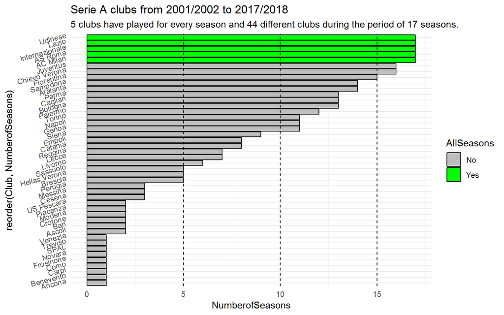

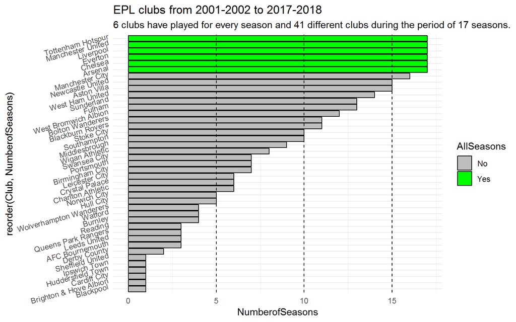

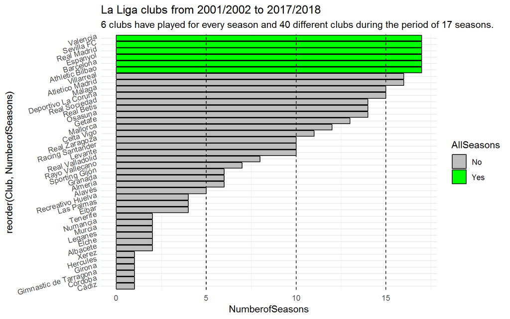

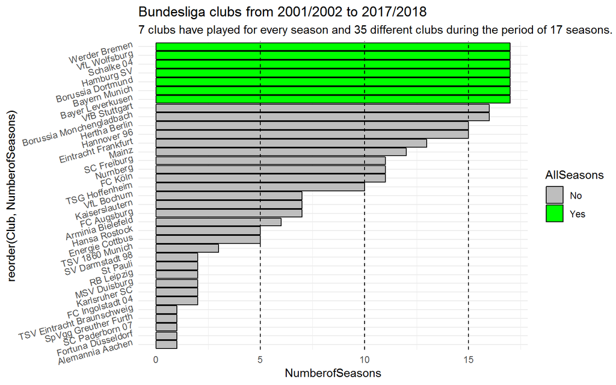

```r
for (i in 1:4) {
  league <- leagues[i,1]
  print(plotseasons(league))
}
```